# Chile and USA transition probabilities

Updated USA calibration: 26 October 2026

SimCRC team

2026-11-05

## Comparison inputs

| Parameter source | Previous comparison | Updated comparison |
| --- | --- | --- |
| USA | Published set v0.13.0.1 | 26 October 2026, v0.15.0 |
| Chile | 21 September 2026, v0.15.0 | Same Chile set |

Both comparisons use the female adenoma model and parameter sets selected for the smallest absolute calibration error.

**Reported probability:** diagnosis within one year, starting in an undiagnosed cancer stage.

The calculation allows cancer to advance and then trigger diagnosis during the same year.

The same original calculation is used throughout. Screening and deaths from other causes are excluded.

## Previous country comparison

USA: published v0.13.0.1. Chile: September 2026 calibration.

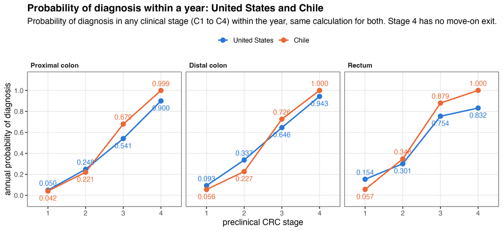

## Updated country comparison

USA: October 2026 calibration. Chile: the same September 2026 calibration.

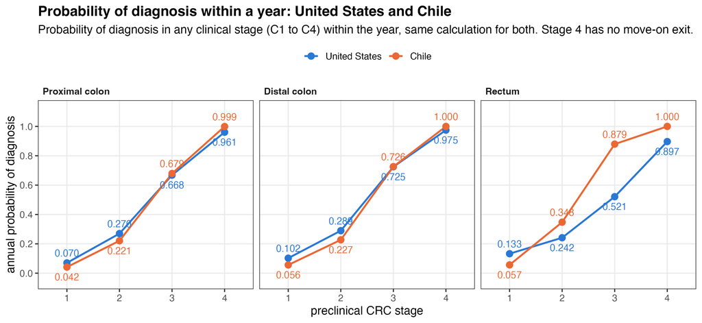

## Change in USA diagnosis probability

One percentage point means an absolute probability difference of 0.01.

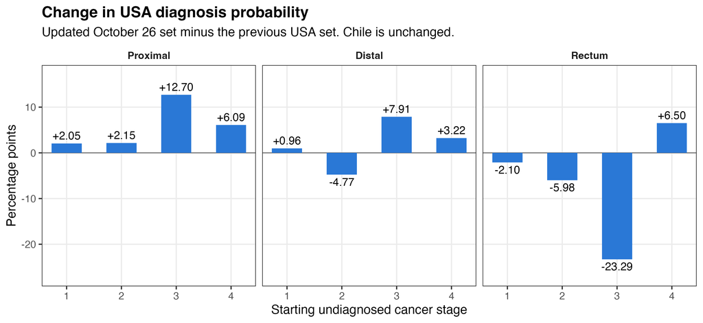

## Diagnosis within one year

| Site | Stage | USA previous | USA updated | Chile | USA change (pp) |
| --- | --- | --- | --- | --- | --- |
| Proximal | 1 | 5.0% | 7.0% | 4.2% | +2.05 |
| Proximal | 2 | 24.8% | 27.0% | 22.1% | +2.15 |
| Proximal | 3 | 54.1% | 66.8% | 67.9% | +12.70 |
| Proximal | 4 | 90.0% | 96.1% | 99.9% | +6.09 |
| Distal | 1 | 9.3% | 10.2% | 5.6% | +0.96 |
| Distal | 2 | 33.7% | 28.9% | 22.7% | -4.77 |
| Distal | 3 | 64.6% | 72.5% | 72.6% | +7.91 |
| Distal | 4 | 94.3% | 97.5% | 100.0% | +3.22 |
| Rectum | 1 | 15.4% | 13.3% | 5.7% | -2.10 |
| Rectum | 2 | 30.1% | 24.2% | 34.8% | -5.98 |
| Rectum | 3 | 75.4% | 52.1% | 87.9% | -23.29 |
| Rectum | 4 | 83.2% | 89.7% | 100.0% | +6.50 |

Probabilities are conditional on the starting stage. Change is updated minus previous USA probability, in percentage points (pp).

## Rectal stage 3

The USA diagnosis probability changes from **75.4% to 52.1%**, a decrease of **23.29 percentage points**.

| Quantity | USA previous | USA updated | Chile |
| --- | --- | --- | --- |
| Diagnosis rate, per year | 1.236 | 0.540 | 1.508 |
| Progression rate, per year | 0.896 | 0.392 | 0.664 |
| Diagnosis within one year | 75.4% | 52.1% | 87.9% |

Both the diagnosis rate and progression rate change in the updated USA set.

A rate describes how quickly an event occurs. The annual probability reflects both events together, including progression followed by diagnosis.